# Between-Sample (Beta) Diversity of the Gut Microbiome in Colorectal Cancer vs. Normal Colon Tissue

Ezra Seckin

April 28, 2026

# Goals

1. Load in phyloseq data with colors and functions.
2. Evaluate sequencing depth and remove samples, if needed.
3. Normalize the read counts between samples.
4. Calculate community **dis**similarities. Numbers between 0 and 1. If 0, completely similar versus if they are 1, then they’re completely dissimilar.
   1. **Sorensen**: Shared Species as a binary value: Abundance-unweighted
   2. **Bray-Curtis**: Shared Abundant species: Abundance-weighted
5. Visualize the community data with two unconstrained Ordinations:
   1. **PCoA**: Linear Method. Eigenvalue = how much variation is explained by each axis. Choose to view axis 1, 2, 3, etc. and plot them together.
   2. **NMDS**: Non-linear. Smush multiple Dimensions into 2 or 3 axes. Need to report Stress value (ideally <0.15).
6. Run statistics with functions from the vegan R package:
   1. PERMANOVA with `adonis2()`.
   2. betadispR with `betadisper()` and `permutest()`.
1. We will need the `preprocessed_physeq.RData` created in `analysis/03_PreProcessing.Rmd`.

## Outputs

*This is an exciting analysis!!! We get to answer another one of our scientific questions!*

1. Calculated beta-diversity dissimilarity measures (*e.g.* Sorensen, Bray-Curtis) across every sample.
2. Ordination figures (*i.e.,* PCoA/NMDS) to include in the scientific paper that visualize the data as it relates to the scientific question.
3. Statistical tests (*i.e.,* PERMANOVA & betadisper) conveying the measured and quantified changes and patterns in beta diversity.

# Scientific Question

How does gut microbial community composition differ between patients with colorectal cancer (CRC) and healthy individuals with normal colon tissue?

- *Null Hypothesis:* Microbial community composition (*e.g.* Sorensen, Bray-Curtis) does not differ between CRC and Normal colon tissue samples.
- *Alternative Hypothesis:* Microbial community composition differs between CRC and Normal samples, reflecting disease-associated shifts in gut microbiome structure.

INTERPRETATION #1: What is your scientific question and hypotheses? Do they relate to abundance-unweighted (presence-absence) or abundance-weighted (relative abundance) metrics?

Our scientific question is: Does gut microbial community composition differ between patients with colorectal cancer (CRC) and healthy individuals with normal colon tissue? The null hypothesis states that microbial community composition does not differ between CRC and Normal samples, while the alternative hypothesis states that it does — reflecting the well-documented disease-associated shifts in gut microbiome structure in colorectal cancer. This question is relevant to both abundance-unweighted and abundance-weighted metrics, and it is important that we capture both. The human gut microbiome harbors a vast repertoire of rare taxa that, despite their low abundance, make biologically significant contributions to the ecology and commensal nature of the gut — including roles in immune modulation, metabolite production, and colonization resistance. The Sorensen dissimilarity (presence/absence) captures whether CRC and Normal communities differ in which taxa are present, including these rare but ecologically important members. The Bray-Curtis dissimilarity (abundance-weighted) captures whether communities differ in the relative abundances of taxa, reflecting disease-associated blooms or depletions of dominant bacterial groups. Running both metrics in parallel allows us to determine whether compositional differences between groups are driven by changes in community membership, shifts in taxon dominance, or both.

# Set up

## Timing of this script

```r
# What time did we start running this script?
start_time <- Sys.time()
```

## Set the seed

```r
set.seed(238428)
```

## Load Packages, colors & functions

```r
pacman::p_load(tidyverse, devtools, phyloseq, patchwork, vegan,
               install = FALSE)

# Load Colors
source("colors_and_shapes.R")

# Load Functions
source("functions.R")
```

# 1. Load in the data

```r
# load phyloseq object
load("data/03_PreProcessing/preprocessed_phyloseq.RData")

# take a look at it!
preprocessed_physeq
```

```
## phyloseq-class experiment-level object
## otu_table()   OTU Table:         [ 7389 taxa and 41 samples ]
## sample_data() Sample Data:       [ 41 samples by 40 sample variables ]
## tax_table()   Taxonomy Table:    [ 7389 taxa by 9 taxonomic ranks ]
```

```r
# Intuition check on seq depth
min(sample_sums(preprocessed_physeq))
```

```
## [1] 68274
```

## Check for and remove outlier samples

Before proceeding, we check whether any samples are clear outliers in terms of sequencing depth or diversity. If identified in previous steps, we remove them here and prune any ASVs unique to those samples.

```r
# If an outlier sample was identified in the biodiversity analysis, remove it here
# Update the sample name below if needed, or skip this step if no outliers were found
# preprocessed_physeq <-
#   preprocessed_physeq %>%
#   subset_samples(names != "YOUR_OUTLIER_SAMPLE_HERE") %>%
#   prune_taxa(taxa_sums(.) > 0, .)

# Check the current number of samples
preprocessed_physeq
```

```
## phyloseq-class experiment-level object
## otu_table()   OTU Table:         [ 7389 taxa and 41 samples ]
## sample_data() Sample Data:       [ 41 samples by 40 sample variables ]
## tax_table()   Taxonomy Table:    [ 7389 taxa by 9 taxonomic ranks ]
```

```r
# Create metadata_df
metadata_df <-
  preprocessed_physeq %>%
  sample_data() %>%
  data.frame()
```

# Normalizing the Read Depth

## 2. Explore the Raw Read Counts

```r
# Calculate read counts per sample
raw_TotalSeqs_df <-
  preprocessed_physeq %>%
  sample_sums() %>%
  data.frame()

# Take a look
head(raw_TotalSeqs_df)
```

```
##                 .
## SRR3666998 192245
## SRR3666999 148226
## SRR3667000 196943
## SRR3667001 139429
## SRR3667002 105951
## SRR3667003  96989
```

```r
# Rename the column
colnames(raw_TotalSeqs_df)[1] <- "TotalSeqs"

# Add a new column of num_ASVs (RAW, non-normalized # ASVs)
raw_TotalSeqsASVs_df <-
  raw_TotalSeqs_df %>%
  mutate(num_ASVs = colSums(otu_table(preprocessed_physeq) > 1))

# Plot histogram of seq depth
rawSeq_histogram <-
  raw_TotalSeqsASVs_df %>%
  ggplot(aes(x = TotalSeqs)) +
  geom_histogram(bins = 50) +
  labs(title = "Raw Seq Depth Histogram") +
  theme_bw()

# Plot Seq Depth versus num_ASVs
rawSeq_vs_numASV_plot <-
  raw_TotalSeqsASVs_df %>%
  ggplot(aes(x = num_ASVs, y = TotalSeqs)) +
  geom_point() +
  geom_smooth(method = "lm") +
  labs(title = "Raw Seq Depth vs # ASVs") +
  theme_bw()

# Is it significant?
summary(lm(TotalSeqs ~ num_ASVs, data = raw_TotalSeqsASVs_df))
```

```
##
## Call:
## lm(formula = TotalSeqs ~ num_ASVs, data = raw_TotalSeqsASVs_df)
##
## Residuals:
##    Min     1Q Median     3Q    Max
## -62641 -31054  -8134  26074  97221
##
## Coefficients:
##              Estimate Std. Error t value Pr(>|t|)
## (Intercept) 107022.06   11634.63   9.199 2.58e-11 ***
## num_ASVs        43.98      18.19   2.418   0.0204 *
## ---
## Signif. codes:  0 '***' 0.001 '**' 0.01 '*' 0.05 '.' 0.1 ' ' 1
##
## Residual standard error: 41230 on 39 degrees of freedom
## Multiple R-squared:  0.1304, Adjusted R-squared:  0.1081
## F-statistic: 5.846 on 1 and 39 DF,  p-value: 0.02038
```

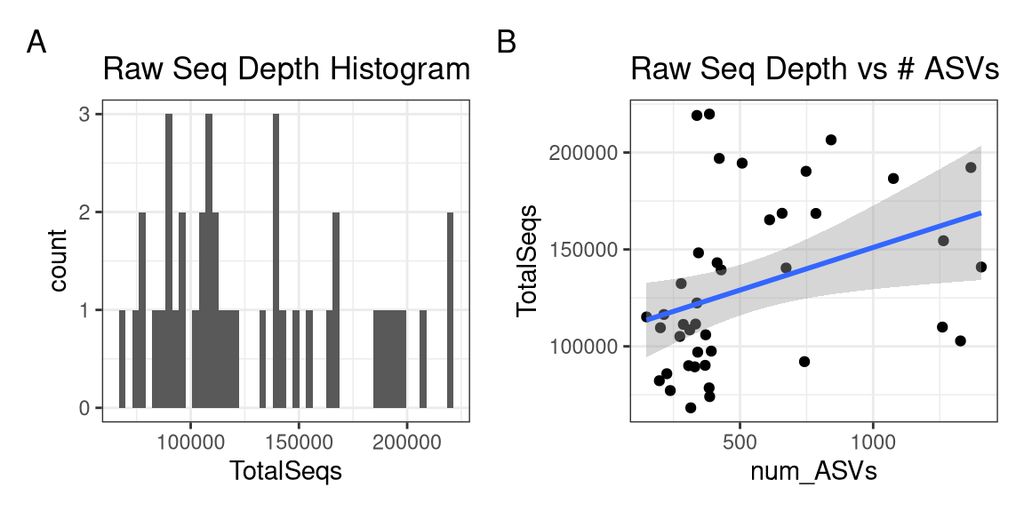

```r
# Put the two plots together.
rawSeq_histogram + rawSeq_vs_numASV_plot +
  plot_annotation(tag_levels = "A")
```

INTERPRETATION #2: Evaluate the raw read count plots above. What did you scale the read counts to in your dataset? Why did you choose that number? What are the potential consequences of this scaling decision for your downstream beta-diversity comparisons?

# 3. Scale Read Counts

```r
min(sample_sums(preprocessed_physeq))
```

```
## [1] 68274
```

```r
# Scale the reads
scaled_physeq <-
  preprocessed_physeq %>%
  scale_reads(round = "matround")

# Look at it
scaled_physeq
```

```
## phyloseq-class experiment-level object
## otu_table()   OTU Table:         [ 7261 taxa and 41 samples ]
## sample_data() Sample Data:       [ 41 samples by 40 sample variables ]
## tax_table()   Taxonomy Table:    [ 7261 taxa by 9 taxonomic ranks ]
```

```r
# Confirm seq read depth of scaled_physeq
scaled_TotalSeqs_df <-
  scaled_physeq %>%
  sample_sums() %>%
  data.frame()

colnames(scaled_TotalSeqs_df)[1] <- "TotalSeqs"

# Add a new column of num_ASVs (scaled # ASVs)
scaled_TotalSeqsASVs_df <-
  scaled_TotalSeqs_df %>%
  mutate(num_ASVs = colSums(otu_table(scaled_physeq) > 1))

# Plot it!
scaledSeq_histogram <-
  scaled_TotalSeqs_df %>%
  ggplot(aes(x = TotalSeqs)) +
  geom_histogram(bins = 50) +
  labs(title = "Scaled Seq Depth Histogram") +
  theme_bw()

# Minimum sequences
min(scaled_TotalSeqs_df$TotalSeqs)
```

```
## [1] 68212
```

```r
# Total Range
range(scaled_TotalSeqs_df)
```

```
## [1] 68212 68306
```

```r
# How many is that range?
range_seqs <- (max(scaled_TotalSeqs_df$TotalSeqs) - min(scaled_TotalSeqs_df$TotalSeqs))
range_seqs
```

```
## [1] 94
```

```r
# And in terms of percent?
range_seqs/max(scaled_TotalSeqs_df$TotalSeqs)
```

```
## [1] 0.00137616
```

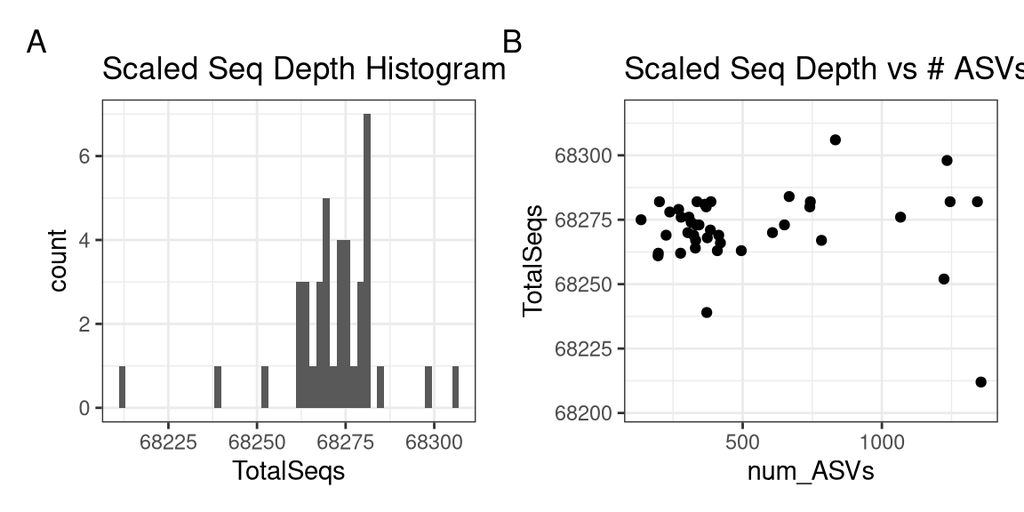

```r
# Set the axis min and max for the next plot
max_y <- max(scaled_TotalSeqs_df$TotalSeqs) + 10
min_y <- min(scaled_TotalSeqs_df$TotalSeqs) - 10

# Now, draw the plot
scaledSeq_vs_numASV_plot <-
  scaled_TotalSeqsASVs_df %>%
  ggplot(aes(x = num_ASVs, y = TotalSeqs)) +
  geom_point() +
  scale_y_continuous(limits = c(min_y, max_y)) +
  theme_bw() +
  labs(title = "Scaled Seq Depth vs # ASVs")

# Put the two plots together.
scaledSeq_histogram + scaledSeq_vs_numASV_plot +
  plot_annotation(tag_levels = "A")
```

INTERPRETATION #3: Evaluate the scaled read count plots above. Are the total number of sequences across all of your samples in the same general range? What is the minimum and maximum (i.e., the range) of the sequencing depth? What does this tell you about the relationship between sequencing depth and the observed number of ASVs?

## Save Scaled Reads

Please do not forget to save your phyloseq object here for any downstream compositional analyses!

```r
save(scaled_physeq, file = "data/05_Ordination/scaled_physeq.RData")
```

# Beta Diversity: Dissimilarity Metrics in Microbial Ecology

## Similarity versus Dissimilarity

In microbial ecology, **beta diversity** refers to the **similarity or dissimilarity**, which represents the uniqueness between two microbial community samples. (Dis)similarity values range from **0 to 1**:

- **Similarity**: Values close to 1 = communities are the same whereas 0 = completely different communities.
- **Dissimilarity**: Values close to 1 = the communities are unique whereas 0 refers to identical communities.

Most ecological studies and ordination plots use **dissimilarity**. For some metrics like Jaccard and Sorensen, you’ll see formulas written as similarity—but it’s easy to convert them.

Different dissimilarity metrics emphasize different aspects of community differences—such as presence/absence, abundance, or evolutionary relatedness (phylogeny). Choosing the right metric depends on your scientific question! It is up to us as data analysts to run each of these dissimilarities on our microbial community samples. This multi-faceted approach will provide a multifaceted view of our microbial communities of interest.

### Why do most ecological studies use **dissimilarity**?

In short: dissimilarity tells us how different things are—just like distance. That’s why it’s the default for ordination, clustering, and most ecological statistics. Most ecological studies and ordination plots use dissimilarity (instead of similarity) for several practical and conceptual reasons:

1. **Distance = Difference is an intuitive interpretation**: Dissimilarity measures provide a sense of how far apart two communities are in terms of their species composition, abundance, or evolutionary history. This framing is intuitive: the more dissimilar two samples are, the greater the distance between them in ecological space.
2. **Ordination methods are built for distances:** Ordination methods such as **Principal Coordinates Analysis (PCoA)** and **Non-metric Multidimensional Scaling (NMDS)** are specifically designed to work with dissimilarity (or distance) matrices. These techniques use dissimilarity values to position samples in a low-dimensional space where the distance between points reflects how different the communities are.
3. **Avoids ambiguity in similarity scaling**: A dissimilarity of 0.2 is straightforward—it tells us that the communities are relatively close, and a value of 0.8 signals they are far apart. This linear and spatial logic makes dissimilarity the more practical choice for ecological analyses.
4. **Consistency across fields and tools**: Dissimilarity metrics are the standard input for most statistical and visualization tools used in microbial ecology, including software packages like QIIME2, phyloseq, and vegan in R.
5. **Easier to identify ecological gradients**: Dissimilarity measures dominate ecological studies and visualizations because they match how we interpret differences in space, work seamlessly with ordination and clustering methods, and provide a clear, consistent framework for understanding ecological patterns.

## Common dissimilarity measures

### How do I choose the right dissimilarity metric?

| Scientific Question | Recommended Metric(s) |
| --- | --- |
| Do the two environments share the same microbes, regardless of abundance? | Jaccard, Sorensen |
| How does abundance differ between communities? | Bray-Curtis |
| Are there differences in the evolutionary history of microbes between samples? | UniFrac (unweighted or weighted) |
| Do dominant, evolutionarily distinct microbes vary in abundance? | Weighted UniFrac |

Choosing the right dissimilarity measure starts with understanding what aspect of community difference you’re trying to capture. If you’re asking whether two environments simply contain the same taxa—regardless of how abundant those taxa are—then presence/absence-based measures like **Jaccard** or **Sorensen-Dice** are appropriate. These metrics are particularly useful when working with rarefied data, or when you’re more concerned with community membership than abundance.

If you’re interested in how **abundant** different taxa are across communities—especially if dominant taxa may be ecologically important—then an abundance-based metric like **Bray-Curtis** is a better choice. Bray-Curtis emphasizes changes in relative abundance and is sensitive to shifts in dominant taxa, making it useful for studying processes like competitive exclusion or resource-driven community turnover.

When your data include **phylogenetic information**—for example, from 16S rRNA gene amplicon sequencing—you may want to use **UniFrac** metrics. **Unweighted UniFrac** is good for detecting evolutionary differences based on presence/absence (i.e., whether the communities harbor different lineages), while **Weighted UniFrac** incorporates both **phylogeny and abundance**, allowing you to explore whether communities differ in their evolutionary makeup **and** in the dominance of certain lineages. These are especially useful when you care about deep evolutionary divergence or when function may correlate with phylogeny.

Practical considerations also matter. For example, UniFrac requires a phylogenetic tree, which takes time and computation to build; Bray-Curtis and Jaccard don’t. Some metrics are also more sensitive to sampling depth and rare taxa, so normalization or rarefaction methods may be necessary before analysis.

In short, let your **ecological question** guide your metric choice: use **presence/absence** metrics to assess “who’s there,” **abundance-based** metrics to examine “how much is there,” and **phylogenetic** metrics to explore “how evolutionarily different are these communities.” Often, using **multiple metrics in parallel** can help reveal different facets of the data and strengthen your ecological interpretations.

These dissimilarity measures are foundational tools in microbial ecology and are often visualized using **ordination methods** (e.g., PCoA, NMDS) to interpret community shifts across environments, treatments, or gradients.

| Metric | Type | Similarity Formula | Dissimilarity Formula | Uses Abundance | Uses Phylogeny |
| --- | --- | --- | --- | --- | --- |
| Jaccard | Presence/absence | $\frac{A}{A+B+C}$ | $\frac{B+C}{A+B+C}$ | ❌ | ❌ |
| Sorensen-Dice | Presence/absence | $\frac{2A}{2A+B+C}$ | $\frac{B+C}{2A+B+C}$ | ❌ | ❌ |
| Bray-Curtis | Abundance-based | — | $\frac{\sum \|a_i - b_i\|}{\sum (a_i + b_i)}$ | ✅ | ❌ |
| Unweighted UniFrac | Phylogenetic + presence/absence | — | $\frac{\text{unique branch}}{\text{total branch}}$ | ❌ | ✅ |
| Weighted UniFrac | Phylogenetic + abundance-based | — | $\frac{\text{weighted unique branch}}{\text{total branch}}$ | ✅ | ✅ |

## Five Types of Dissimilarities

### A. Jaccard Dissimilarity

- **Type:** Presence/absence
- **Formula:**
  $$D_J = \frac{B + C}{A + B + C}$$
  Where:
  - *A* = number of taxa shared by both samples
  - *B* = taxa unique to sample 1
  - *C* = taxa unique to sample 2
- **Interpretation:** Measures dissimilarity in community **membership**—i.e., how many taxa are **not shared** between the samples.
- **Ecological question:** *How unique are the species between two communities, ignoring abundance?*

### B. Sorensen-Dice Dissimilarity

- **Type:** Presence/absence (weighted toward shared taxa)
- **Similarity formula**:
  $$S_S = \frac{2A}{2A + B + C}$$
- **Dissimilarity formula**:
  $$D_S = 1 - S_S = \frac{B + C}{2A + B + C}$$
- **Interpretation:** Similar to Jaccard, but gives **greater weight to shared taxa**, making it more sensitive to overlap in community membership. The Sorensen-Dice is mathematically similar to Bray-Curtis, which makes it a nice side-by-side comparison with Bray-Curtis.
- **Ecological question:** *To what extent do two communities differ in presence/absence, giving extra credit for shared species?*

### C. Bray-Curtis Dissimilarity

- **Type:** Abundance-based
- **Formula:**
  $$BC_{AB} = \frac{\sum_{k=1}^{S} \left| x_{Ak} - x_{Bk}
  \right|}{\sum_{k=1}^{S} \left( x_{Ak} + x_{Bk} \right)}$$
  Where:
  - $BC_{AB}$: Bray-Curits dissimilarity between sample **A** and sample **B**.
  - *S*: Total number of species or ASVs.
  - $x_{Ak}$: Abundance of species *k* in sample **A**
  - $x_{Bk}$: Abundance of species *k* in sample **B**
- **Interpretation:** Quantifies dissimilarity based on **abundance differences**—especially sensitive to changes in dominant taxa. Often, it is run together with the Sorensen-Dice dissimilarity as these two metrics are mathematically similar.
- **Ecological question:** *How different are two communities in terms of the* *abundance* *of shared and unique taxa?*

### D. Unweighted UniFrac Dissimilarity

- **Type:** Phylogenetic, presence/absence
- **Formula (conceptual):**
  $$D_{UU} = \frac{\text{Unique branch length}}{\text{Total branch length}}$$
- **Interpretation:** Measures the proportion of **phylogenetic branch lengths** that are unique to either sample, ignoring abundance. This measure requires a curated and a rooted tree, ideally within a meaningful outgroup, like the Archaea. The curation and visual inspection of the tree is important as this metric is very sensitive to long branches! Therefore, we need to do our diligence with the quality of our input tree.
- **Ecological question:** *How evolutionarily distinct are the community members between samples, regardless of how abundant they are?*

### E. Weighted UniFrac Dissimilarity

- **Type:** Phylogenetic, abundance-weighted
- **Formula (conceptual):**
  $$D_{WU} = \frac{\text{Abundance-weighted unique branch
  length}}{\text{Total branch length}}$$
- **Interpretation:** Combines **phylogeny and abundance**—emphasizes both how evolutionarily distinct and how **numerically different** the communities are, giving more weight to abundant taxa. This measure requires a curated and a rooted tree, ideally within a meaningful outgroup, like the Archaea. The curation and visual inspection of the tree is important as this metric is very sensitive to long branches! Therefore, we need to do our diligence with the quality of our input tree.
- **Ecological question:** *How much do two communities differ in the* *abundance of evolutionarily distinct* *lineages?*

# 4. Calculating dissimilarity

Now, let’s make distance objects of each of the dissimilarity measures. Since we do not have a rooted phylogenetic tree in this dataset, we will focus on Sorensen and Bray-Curtis dissimilarity.

```r
# Sorensen Dissimilarity (presence/absence)
scaled_sorensen_dist <- phyloseq::distance(scaled_physeq, method = "bray", binary = TRUE)

class(scaled_sorensen_dist)
```

```
## [1] "dist"
```

```r
str(scaled_sorensen_dist)
```

```
##  'dist' num [1:820] 0.795 0.776 0.761 0.789 0.768 ...
##  - attr(*, "maxdist")= num 1
##  - attr(*, "Size")= int 41
##  - attr(*, "Labels")= chr [1:41] "SRR3666998" "SRR3666999" "SRR3667000" "SRR3667001" ...
##  - attr(*, "Diag")= logi FALSE
##  - attr(*, "Upper")= logi FALSE
##  - attr(*, "method")= chr "binary bray"
##  - attr(*, "call")= language vegdist(x = c(3760, 799, 22, 12, 347, 860, 9710, 7138, 27, 3361, 25, 48,  8358, 53, 1641, 359, 352, 483, 26348, 1| __truncated__ ...
```

```r
# Bray-Curtis Dissimilarity (abundance-weighted)
scaled_bray_dist <- phyloseq::distance(scaled_physeq, method = "bray", binary = FALSE)

# UniFrac metrics are commented out as they require a rooted phylogenetic tree, which we don't have
# scaled_uUnifrac_dist <- phyloseq::distance(scaled_physeq, method = "unifrac")
# scaled_wUnifrac_dist <- phyloseq::distance(scaled_physeq, method = "wunifrac")
```

INTERPRETATION #4: Which dissimilarity metric is most related to your scientific question? Why or why not?

Both Sorensen and Bray-Curtis dissimilarity are relevant to our scientific question, and we will use both in parallel — but for different reasons. Our primary question asks whether gut microbial community composition differs between CRC and Normal colon tissue samples, which inherently has two dimensions: changes in which taxa are present and changes in how abundant those taxa are. The Bray-Curtis dissimilarity is arguably most directly aligned with our scientific question. CRC is associated with well-documented shifts in the relative abundances of specific bacterial taxa — including blooms of pathobionts like Fusobacterium nucleatum and depletions of butyrate-producing commensals like Faecalibacterium prausnitzii. These are fundamentally abundance-based phenomena, and Bray-Curtis is specifically sensitive to these kinds of dominant taxon shifts. It will capture whether the CRC microbiome is not just compositionally different in membership, but also ecologically reorganized in terms of which taxa dominate. However, the Sorensen dissimilarity is equally important to include. As noted above, the human gut microbiome harbors a vast repertoire of rare taxa that make biologically significant contributions to gut ecology and commensalism — including roles in immune education, competitive exclusion of pathogens, and short-chain fatty acid production. Sorensen treats all taxa equally regardless of abundance, making it sensitive to the loss or gain of rare but ecologically important community members that Bray-Curtis might overlook. Running both metrics together gives us the most complete picture: Sorensen tells us whether CRC and Normal communities differ in who is there, while Bray-Curtis tells us whether they differ in who dominates.

# 5. Visualize Community Dissimilarity with Ordination

## What are ordination methods?

**TLDR: Ordination = dimensionality reduction for complex ecological data.**

**Ordination methods** are a family of multivariate statistical techniques used to reduce the dimensionality of complex datasets and visualize patterns of similarity or dissimilarity among samples. In microbial ecology and community ecology more broadly, ordination helps reveal how microbial communities differ across samples based on environmental gradients, treatments, or other metadata.

Microbial community data (*e.g.,* 16S rRNA, metagenomics) often involve thousands of taxa across dozens to hundreds of samples. Ordination condenses this complexity into 2–3 axes that capture the main trends in community variation, allowing you to:

- Visualize clustering of similar samples
- Assess whether treatment groups (e.g., CRC vs. Normal) separate in multivariate space
- Explore community response to clinical or biological variables

## Key Types of Ordination Methods

Please see the [Paliy & Shankar (2016)](https://onlinelibrary.wiley.com/doi/10.1111/mec.13536) paper for a great background and overview of various ordination methods. In summary:

| Method | Type | Preserves | Typical Use Case |
| --- | --- | --- | --- |
| **PCA** (Principal Component Analysis) | Linear, metric | Euclidean distances | Abundance data, normalized counts |
| **PCoA** (Principal Coordinates Analysis) | Metric | Any dissimilarity metric | Bray-Curtis, Jaccard, UniFrac; interpretable axes |
| **NMDS** (Non-metric Multidimensional Scaling) | Non-metric | Rank order of dissimilarities | Complex, nonlinear ecological data; robust to outliers |
| **CA** (Correspondence Analysis) | Linear, unimodal response | Chi-squared distances | Species-by-site tables; assumes unimodal species response curves |
| **CCA** (Canonical Correspondence Analysis) | Constrained ordination | Unimodal + environmental drivers | Explains variation using environmental variables |
| **RDA** (Redundancy Analysis) | Constrained ordination | Linear + environmental drivers | Like PCA but incorporates environmental predictors |

In practice, the most common ordination methods in microbial ecology are:

1. **PCoA** - Eigen-based analysis, linear, axis coefficients are meaningful because they represent the eigenvectors.
2. **NMDS** - Non-linear method, axes are not meaningful, smush many axes of data into 2 axes

| Aspect | PCoA | NMDS |
| --- | --- | --- |
| **Basis** | Metric ordination (preserves distances) | Non-metric (preserves rank order) |
| **Output** | Axes with eigenvalues (% variance explained) | Configuration with stress value |
| **Assumptions** | Assumes distances can be represented in Euclidean space | No assumptions about linearity |
| **Advantages** | Quantitative variance breakdown; interpretable axes | Robust to outliers and non-linear relationships |
| **Limitations** | Sensitive to outliers; negative eigenvalues possible | Axes are arbitrary; requires iterative optimization |
| **Usage in Microbial Ecology** | Good when variance explained is important | Often preferred for complex, non-linear ecological data |

## 5a. PCoA: Principal Coordinates Analysis

**PCoA** starts with a distance (or dissimilarity) matrix calculated from microbial community data (e.g., Bray-Curtis, Jaccard) and then uses eigen decomposition to project samples into a low-dimensional space (typically 2 or 3 dimensions). PCoA is a metric technique — it strives to preserve the actual distances between samples.

**PCoA is eigen-based:** The method produces **eigenvalues** for each coordinate, which can be interpreted as the proportion of total variation explained by that axis.

- **Eigenvalues** tell us how well our ordination captures the variability in beta diversity.
- **Eigenvectors** tell us where each sample falls along major ecological gradients, even if those gradients are not explicitly labeled.

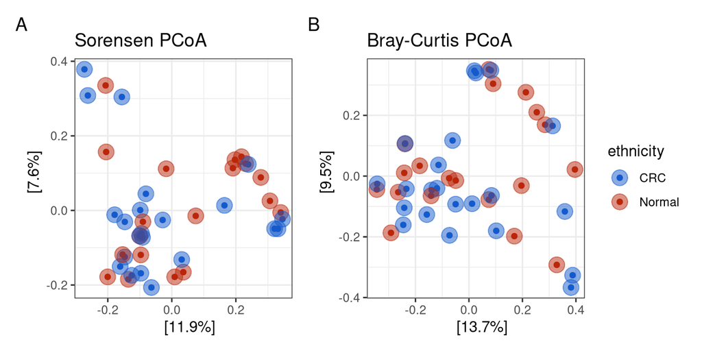

```r
### SORENSEN
# Calculate PCoA with Sorensen
scaled_soren_pcoa <-
  ordinate(physeq = scaled_physeq,
         method = "PCoA",
         distance = "bray", binary = TRUE)

# Plot it: Sorensen PCoA
sorensen_pcoa_plot <-
  plot_ordination(physeq = scaled_physeq,
                ordination = scaled_soren_pcoa,
                color = "ethnicity",
                title = "Sorensen PCoA") +
  scale_color_manual(values = crc_colors) +
  geom_point(size = 5, alpha = 0.5, aes(color = ethnicity)) +
  theme_bw() +
  theme(legend.position = "right")
### Bray-Curtis
# Calculate PCoA with Bray-Curtis
scaled_bray_pcoa <-
  ordinate(physeq = scaled_physeq,
         method = "PCoA",
         distance = "bray", binary = FALSE)

# Plot it: Bray-Curtis PCoA
bray_pcoa_plot <-
  plot_ordination(physeq = scaled_physeq,
                ordination = scaled_bray_pcoa,
                color = "ethnicity",
                title = "Bray-Curtis PCoA") +
  scale_color_manual(values = crc_colors) +
  geom_point(size = 5, alpha = 0.5, aes(color = ethnicity)) +
  theme_bw() +
  theme(legend.position = "right")

# Show the plots
sorensen_pcoa_plot + bray_pcoa_plot +
  plot_layout(guides = "collect") +
  plot_annotation(tag_levels = "A")
```

Above are two PCoA (Principal Coordinates Analysis) plots showing differences in microbial community composition between Normal and CRC colon tissue samples:

- **Left (Panel A):** Sorensen dissimilarity (presence/absence-based)
- **Right (Panel B):** Bray-Curtis dissimilarity (abundance-weighted)

INTERPRETATION #5: Plot your data using a PCoA. Interpret what you can conclude from the PCoA. Do CRC and Normal samples appear to separate in ordination space? Does the Bray-Curtis plot tell a different story than the Sorensen plot?

## 5b. NMDS: Non-Metric Multidimensional Scaling

**Non-metric Multidimensional Scaling (NMDS)** is a rank-based ordination method commonly used in microbial ecology to visualize differences in community composition. Unlike metric methods like PCoA, *NMDS does not preserve exact distances but instead maintains the rank order of dissimilarities between samples*. This makes it well-suited for ecological data that are high-dimensional, non-linear, and zero-inflated.

NMDS works by iteratively arranging samples in a low-dimensional space (typically 2D) to best match the original distance rankings from a dissimilarity matrix. The quality of the fit is measured by **stress** — lower stress indicates a better match.

- **Stress < 0.1** is often reported as a strong result.
- **Stress < 0.2** is still commonly accepted but it’s best if < 0.15, especially with complex, high-diversity microbiome data.
- It’s common to see NMDS with stress values between 0.08–0.15 in published studies.

*Okay, let’s draw some NMDS plots!*

```r
## SORENSEN
scaled_soren_nmds <-
  ordinate(physeq = scaled_physeq,
         method = "NMDS",
         distance = "bray", binary = TRUE)
```

```
## Square root transformation
## Wisconsin double standardization
## *** Best solution was not repeated -- monoMDS stopping criteria:
##     20: stress ratio > sratmax
```

```r
# Plot it!
sorensen_nmds_plot <-
  plot_ordination(physeq = scaled_physeq,
                ordination = scaled_soren_nmds,
                color = "ethnicity",
                title = "Sorensen NMDS") +
  scale_color_manual(values = crc_colors) +
  geom_point(size = 5, alpha = 0.5, aes(color = ethnicity)) +
  theme_bw() +
  theme(legend.position = "right")

### Bray-Curtis
scaled_bray_nmds <-
  ordinate(physeq = scaled_physeq,
         method = "NMDS",
         distance = "bray", binary = FALSE)
```

```
## Square root transformation
## Wisconsin double standardization
## *** Best solution was not repeated -- monoMDS stopping criteria:
##     20: stress ratio > sratmax
```

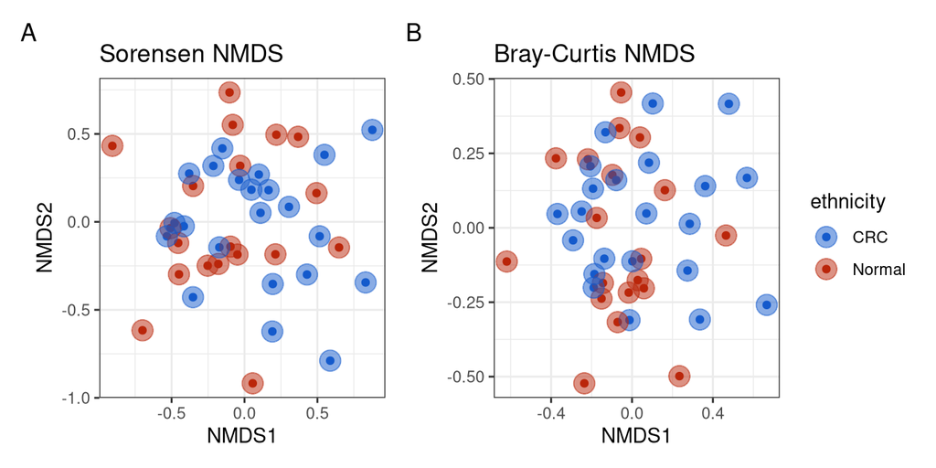

```r
# Plot it: Bray-Curtis NMDS
bray_nmds_plot <-
  plot_ordination(physeq = scaled_physeq,
                ordination = scaled_bray_nmds,
                color = "ethnicity",
                title = "Bray-Curtis NMDS") +
  scale_color_manual(values = crc_colors) +
  geom_point(size = 5, alpha = 0.5, aes(color = ethnicity)) +
  theme_bw() +
  theme(legend.position = "right")

# Show the plots
sorensen_nmds_plot + bray_nmds_plot +
  plot_layout(guides = "collect") +
  plot_annotation(tag_levels = "A")
```

INTERPRETATION #6: Plot your data using NMDS and interpret the results. How does the NMDS compare to the PCoA you generated in Interpretation #5? Do the two ordination methods tell a consistent story, or do you notice any differences in how the samples are arranged? Make sure to report the stress value and comment on whether it is acceptable.

## All ordinations together!

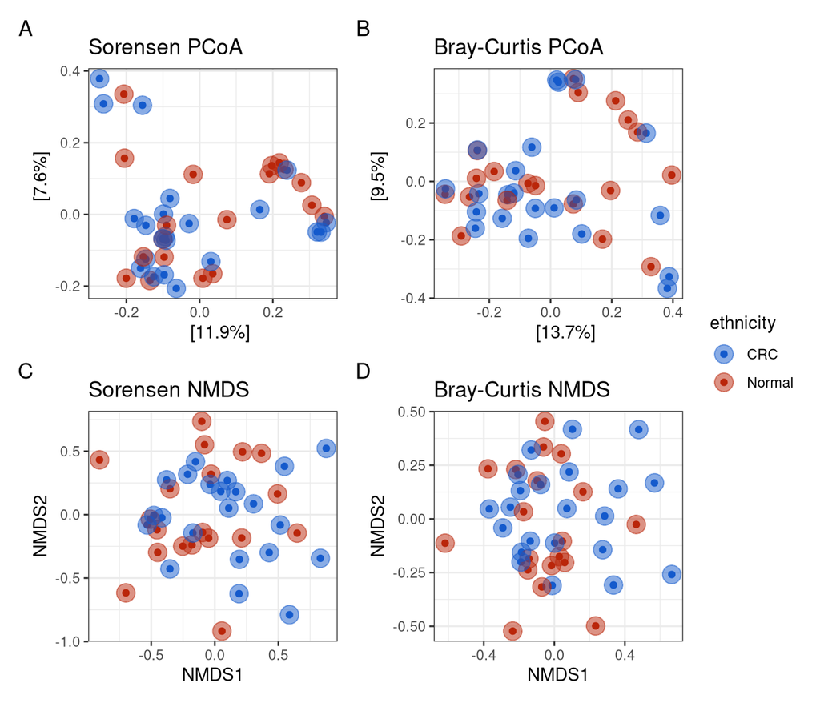

```r
sorensen_pcoa_plot + bray_pcoa_plot +
sorensen_nmds_plot + bray_nmds_plot +
  plot_layout(guides = "collect") +
  plot_annotation(tag_levels = "A")
```

INTERPRETATION #7: Plot both the PCoA and NMDS together. Which of the two ordination methods best represents your data and why? Consider the strengths and limitations of each method. For example, the variance explained by each PCoA axis versus the stress value of the NMDS could be used to justify your choice. Do both methods support the same biological conclusions?

# 6. Multivariate Statistics

## 6a. PERMANOVA: Testing Means/Centroids

The goal of PERMANOVA is to ask: *Do the centroids (i.e., means) differ between groups?*

**PERMANOVA** stands for **Permutational Multivariate Analysis of Variance**. It is a statistical test used in microbial ecology to determine whether the composition of microbial communities differs significantly between groups — for example, between CRC and Normal colon tissue samples.

Unlike traditional ANOVA, which compares means of univariate data, PERMANOVA works on a **distance or dissimilarity matrix** (like Bray-Curtis). It assesses whether the **centroids** (multivariate means) of different groups in that distance space are significantly farther apart than we’d expect by chance. The test uses permutations to randomly shuffle group labels and calculate a distribution of test statistics, allowing it to compute a **p-value** without assuming normality.

However, PERMANOVA is **sensitive to differences in within-group dispersion** (*i.e.,* variability). If one group is much more variable than another, PERMANOVA might detect a significant result even if the centroids aren’t truly different. Because of this, it’s good practice to also run a **test for homogeneity of dispersion** (*e.g.,* `betadisper` in R) to check that group variances are comparable.

**Key Parameters in `adonis2()`**

- `by = "terms"`: tests each term sequentially — sensitive to term order.
- `by = "margin"`: tests each term while adjusting for others.
- `by = "none"`: tests only the full model.

### 6a-I. Categorical Variables

Here, we focus on CRC status (`ethnicity`: Normal vs. CRC) as our primary categorical variable of interest.

#### Sorensen

```r
# Sorensen — test ethnicity (CRC status)
## Run with by = "terms" to get R² values
## Run in two orders to check sensitivity to term order
sorensen_crcGroup_adonis_terms1 <- adonis2(scaled_sorensen_dist ~ ethnicity, data = metadata_df, by = "terms")
sorensen_crcGroup_adonis_terms1
```

```
## Permutation test for adonis under reduced model
## Terms added sequentially (first to last)
## Permutation: free
## Number of permutations: 999
##
## adonis2(formula = scaled_sorensen_dist ~ ethnicity, data = metadata_df, by = "terms")
##           Df SumOfSqs      R2      F Pr(>F)
## ethnicity  1   0.2032 0.01696 0.6727  0.967
## Residual  39  11.7825 0.98304
## Total     40  11.9857 1.00000
```

**Understanding PERMANOVA output:**

- **Pr(>F):** The p-value — probability of observing an F-statistic this extreme assuming the null hypothesis is true.
- **R² value:** How much variation is explained by this variable — an effect size. R² = 0.25 means that the term explains 25% of the variation in community composition.
- **F-statistic:** How strongly a variable separates groups, relative to residuals. Higher F-values indicate stronger group separation.

#### Bray-Curtis

```r
# Bray-Curtis — test ethnicity (CRC status)
bray_crcGroup_adonis_terms1 <- adonis2(scaled_bray_dist ~ ethnicity, data = metadata_df, by = "terms")
bray_crcGroup_adonis_terms1
```

```
## Permutation test for adonis under reduced model
## Terms added sequentially (first to last)
## Permutation: free
## Number of permutations: 999
##
## adonis2(formula = scaled_bray_dist ~ ethnicity, data = metadata_df, by = "terms")
##           Df SumOfSqs      R2     F Pr(>F)
## ethnicity  1   0.2397 0.01659 0.658  0.929
## Residual  39  14.2067 0.98341
## Total     40  14.4464 1.00000
```

### Comparing Sorensen & Bray-Curtis PERMANOVA Results

After running both models, compare:

1. Does CRC status explain a significant proportion of variation in community composition in either metric?
2. Is the R² higher in Bray-Curtis than Sorensen? If so, this suggests that abundance shifts — not just presence/absence turnover — contribute to community differences between CRC and Normal samples.
3. What proportion of variance remains unexplained (residuals)? High residuals are expected in complex human microbiome datasets due to inter-individual variability.

INTERPRETATION #8: Run the appropriate PERMANOVA for your scientific question and interpret the results. What biological conclusion can you draw from your PERMANOVA results, and do you accept or reject your hypothesis?

# 6b. Betadisper: Testing Variances/Dispersions

`betadisper()` is an important companion to PERMANOVA when analyzing beta diversity in microbial ecology. It checks a key assumption of PERMANOVA: **homogeneity of group dispersions (variances)**. If this assumption is violated, the PERMANOVA results might be driven by differences in spread rather than true differences in community composition.

We will use the `betadisper()` and then the `permutest()` functions from the vegan package in R, which will perform an analysis of multivariate homogeneity of group dispersions — also called a PERMDISP test.

`betadisper()` will:

1. Input a distance matrix and a grouping factor (e.g., `ethnicity`).
2. Calculate the centroid of each group in multivariate space (via PCoA).
3. Compute the distance from each sample to its group’s centroid.
4. Store those distances — these are the within-group dispersions.

`permutest()` will then test whether those dispersions differ significantly between groups using a permutation-based ANOVA.

**Always run `betadisper()` and `permutest()` after PERMANOVA** to test whether the groups have similar within-group variation.

- If p > 0.05 (not significant), the PERMANOVA result is reliable.
- If p < 0.05 (significant), be cautious — group differences may be due to dispersion, not composition. However, this is not necessarily the end of the world — biological processes can also cause differences in dispersion (e.g., greater community variability in disease states).

**In Summary:**

| Function | What it does | Significance test? | Output includes |
| --- | --- | --- | --- |
| `betadisper()` | Computes within-group distances to centroids (dispersion) | ❌ No | Distances, centroids, model object |
| `permutest()` | Tests if group dispersions differ using permutations | ✅ Yes | F-value, permutation-based p-value |

### Sorensen

```r
# Sorensen Betadisper - CRC Status (Categorical)
dispr_sorensen_crcGroup <- betadisper(scaled_sorensen_dist, metadata_df$ethnicity)
permutest(dispr_sorensen_crcGroup)
```

```
##
## Permutation test for homogeneity of multivariate dispersions
## Permutation: free
## Number of permutations: 999
##
## Response: Distances
##           Df   Sum Sq    Mean Sq      F N.Perm Pr(>F)
## Groups     1 0.000239 0.00023872 0.1043    999  0.748
## Residuals 39 0.089298 0.00228970
```

### Bray-Curtis

```r
# Bray-Curtis Betadisper - CRC Status (Categorical)
dispr_bray_crcGroup <- betadisper(scaled_bray_dist, metadata_df$ethnicity)
permutest(dispr_bray_crcGroup)
```

```
##
## Permutation test for homogeneity of multivariate dispersions
## Permutation: free
## Number of permutations: 999
##
## Response: Distances
##           Df  Sum Sq  Mean Sq      F N.Perm Pr(>F)
## Groups     1 0.01363 0.013635 1.2889    999  0.235
## Residuals 39 0.41257 0.010579
```

## What if PERMANOVA and Betadisper tests are both significant?

If **PERMANOVA is significant** *and* **betadisper is also significant**, it suggests that:

- Your groups **differ in community composition** (centroids), **but** also
- They may **differ in dispersion** (variance/spread), which can influence the PERMANOVA result

This raises the possibility that the PERMANOVA significance is at least partly driven by **differences in group variability**, not just true compositional shifts. In the context of CRC research, this could actually be biologically meaningful — disease states are often associated with greater within-group microbiome variability, reflecting ecological instability in the gut community.

| Scenario | Interpretation |
| --- | --- |
| ✅ PERMANOVA significant ❌ betadisper not significant | Likely true compositional differences (valid PERMANOVA result) |
| ✅ PERMANOVA significant ✅ betadisper significant | Differences may be due to dispersion, not centroids — interpret with caution |

**Next steps if both are significant:**

- Reflect on the ordination plots above to visually assess whether centroids are distinct or just differently dispersed.
- Consider whether greater within-group variability in CRC samples is itself a biologically meaningful finding.
- Interpret PERMANOVA results with appropriate caveats.

> Even with unequal dispersion, true ecological differences can still exist — the key is to **interpret with care** and use supporting evidence.

INTERPRETATION #9: Run the appropriate betadisper() and permutest() for your scientific question and interpret the results. What biological conclusion can you draw from your dispersion analysis?

INTERPRETATION #10: Taking into account both the betadisper()/permutest() and the PERMANOVA (adonis2()) test that you ran, what biological conclusion can you draw regarding your data?

# Final info for Reproducibility

## Check Render Time

```r
# Take the time now that we are at the end of the script
end_time <- Sys.time()
end_time
```

```
## [1] "2026-04-28 13:02:03 EDT"
```

```r
# Echo the elapsed time
elapsed_time <- round((end_time - start_time), 3)
elapsed_time
```

```
## Time difference of 12.026 secs
```